# Inference for numerical data

## Exploratory analysis

Load the `nc` data set into our workspace.

```r
library(dplyr)
library(ggplot2)
library(oilabs)
head(nc)
```

```
##   fage mage      mature weeks    premie visits marital gained weight
## 1   NA   13 younger mom    39 full term     10 married     38   7.63
## 2   NA   14 younger mom    42 full term     15 married     20   7.88
## 3   19   15 younger mom    37 full term     11 married     38   6.63
## 4   21   15 younger mom    41 full term      6 married     34   8.00
## 5   NA   15 younger mom    39 full term      9 married     27   6.38
## 6   NA   15 younger mom    38 full term     19 married     22   5.38
##   lowbirthweight    sex     habit  whitemom
## 1        not low   male nonsmoker not white
## 2        not low   male nonsmoker not white
## 3        not low female nonsmoker     white
## 4        not low   male nonsmoker     white
## 5        not low female nonsmoker not white
## 6            low   male nonsmoker not white
```

1. What are the cases in this data set? How many cases are there in our sample?

*Each case corresponds to one birth in NC in 2004. There are 1000 such cases.*

2. As you review the variable summaries, consider which variables are categorical and which are numerical. For numerical variables, are there outliers? If you aren’t sure or want to take a closer look at the data, make a plot.

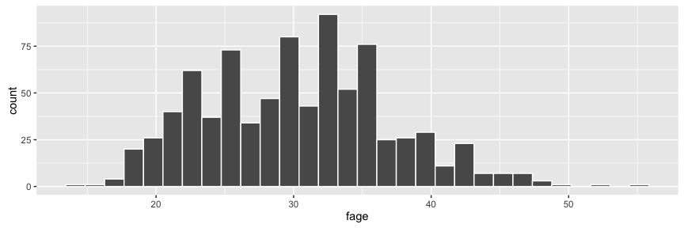

```r
qplot(data = nc, x = fage, color = I("white"))
```

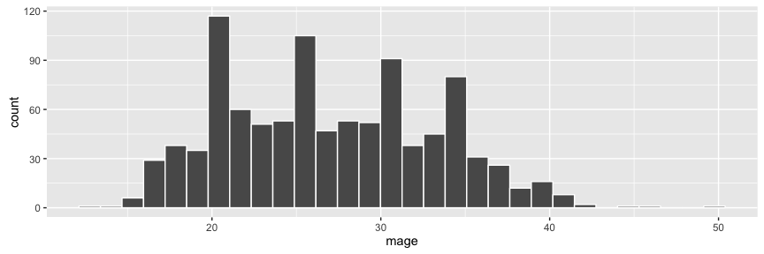

```r
qplot(data = nc, x = mage, color = I("white"))
```

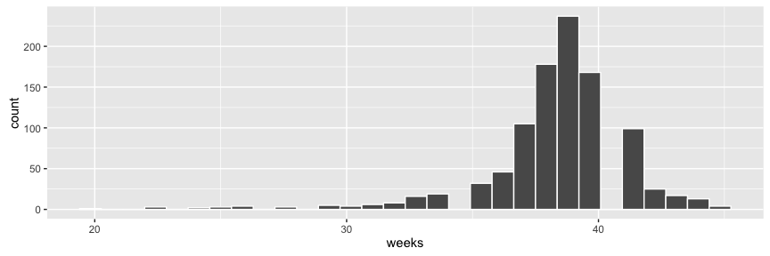

```r
qplot(data = nc, x = weeks, color = I("white"))
```

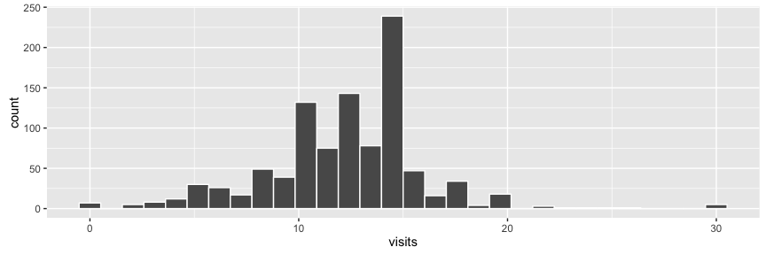

```r
qplot(data = nc, x = visits, color = I("white"))
```

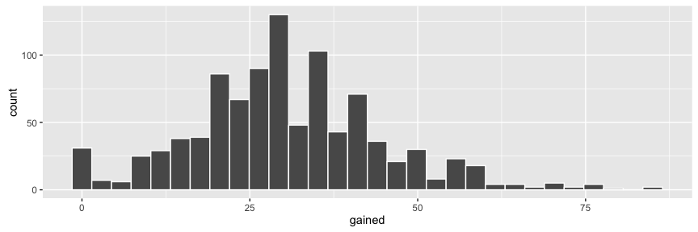

```r
qplot(data = nc, x = gained, color = I("white"))
```

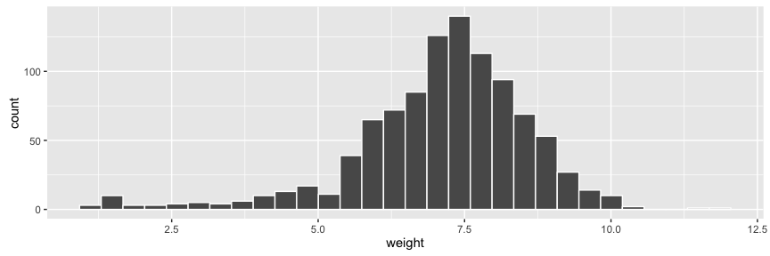

```r
qplot(data = nc, x = weight, color = I("white"))
```

*There appears to be outliers with each numerical variable.*

2. Make a side-by-side boxplot of `habit` and `weight`. What does the plot highlight about the relationship between these two variables?

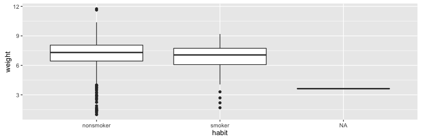

```r
qplot(x = habit, y = weight, data = nc, geom = "boxplot")
```

*The plot reveals that there are some missing values for this variable. Between smokers and non-smokers, the former has a slightly lower Q1, Q2, and Q3 birth weight compared to the latter. Both show evidence of a left skew, though the larger number of low outliers in the nonsmoker group is probably due simply to the fact that there were more of them.*

## Inference

3. Write the hypotheses for testing if the average weights of babies born to smoking and non-smoking mothers are different.

$$H_0: \mu_{smoking} = \mu_{nonsmoking}; \quad \textrm{or} \quad \mu_{smoking} - \mu_{nonsmoking} = 0$$
$$H_A: \mu_{smoking} - \mu_{nonsmoking} \neq 0$$

*where $\mu$ is the mean birthweight within each group*.

4. What is our test statistic? What distribution would you expect it to follow

*The test statistic is*

$$T = \dfrac{\bar{X}_{smoking} - \bar{X}_{nonsmoking}}{SE \text{ of } \bar{X}_{smoking} - \bar{X}_{nonsmoking}}$$

*where*

$$SE \text{ of } \bar{X}_{smoking} - \bar{X}_{nonsmoking} = \sqrt{\dfrac{s_{smoking}^2}{n_{smoking}} + \dfrac{s_{nonsmoking}^2}{n_{nonsmoking}}}.$$

*We expect it to follow a $t$ distribution with 125 degrees of freedom or the Normal distribution.*

4. Check if the conditions necessary for inference are satisfied. Note that you will need to obtain sample sizes to check the conditions. You can compute the group size using the same chain above but replacing summarizing each group with `n()` instead of `mean(weight)`.

*There are several assumptions we’re making if we model the above test statistic using the t-distribution. The first is that each observation is independent of one another. As this is a random sample of all (very large number of) births in NC in 2004, that assumption is reasonable.*

*The second assumption is the population within each group is nearly normally distributed. As we saw in the boxplots above, there is some evidence of left skew. However, we see that the number of observations in each group is quite high:*

```r
nc %>%
  group_by(habit) %>%
  summarize(n())
```

```
## Source: local data frame [3 x 2]
##
##       habit   n()
##      <fctr> <int>
## 1 nonsmoker   873
## 2    smoker   126
## 3        NA     1
```

*Because of this, the nearly normal condition can be relaxed as the central limit theorem is beginning to kick in. Furthermore, at this large a number of observations, even though we don’t know $\sigma$, our estimate using $s$ will be pretty good, so this sampling distribution will also be well-approximated by the Normal distribution.*

5. Change the `type` argument to `"ci"` to construct and record a confidence interval for the difference between the weights of babies born to smoking and non-smoking mothers.

```r
inference(y = nc$weight, x = nc$habit, est = "mean", type = "ci", null = 0,
          alternative = "twosided", method = "theoretical")
```

```
## Response variable: numerical, Explanatory variable: categorical
## Difference between two means
## Summary statistics:
## n_nonsmoker = 873, mean_nonsmoker = 7.1443, sd_nonsmoker = 1.5187
## n_smoker = 126, mean_smoker = 6.8287, sd_smoker = 1.3862
```

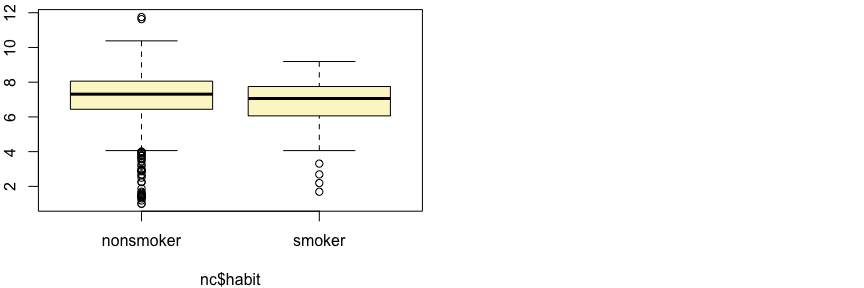

```
## Observed difference between means (nonsmoker-smoker) = 0.3155
##
## Standard error = 0.1338
## 95 % Confidence interval = ( 0.0534 , 0.5777 )
```

*The 95% confidence interval for the true difference between mean birth weights of babies born to smoking and non-smoking mothers is (.0534, .5777).*

By default the function reports an interval for ($\mu_{nonsmoker} - \mu_{smoker}$) . We can easily change this order by using the `order` argument:

```r
inference(y = nc$weight, x = nc$habit, est = "mean", type = "ci", null = 0,
          alternative = "twosided", method = "theoretical",
          order = c("smoker","nonsmoker"))
```

```
## Response variable: numerical, Explanatory variable: categorical
## Difference between two means
## Summary statistics:
## n_smoker = 126, mean_smoker = 6.8287, sd_smoker = 1.3862
## n_nonsmoker = 873, mean_nonsmoker = 7.1443, sd_nonsmoker = 1.5187
```

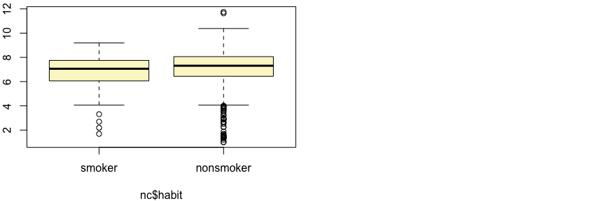

```
## Observed difference between means (smoker-nonsmoker) = -0.3155
##
## Standard error = 0.1338
## 95 % Confidence interval = ( -0.5777 , -0.0534 )
```

## On your own

For the following inferential exercises, be sure to assess the conditions for inference.

- Calculate a 95% confidence interval for the average length of pregnancies (`weeks`) and interpret it in context. Note that since you’re doing inference on a single population parameter, there is no explanatory variable, so you can omit the `x` variable from the function.

*As this is a random sample, our observations are independent. There is some left skew in the distribution of `weeks`, but the sample size is sufficient that the nearly normal condition can be relaxed.*

```r
inference(y = nc$weeks, est = "mean", type = "ci", method = "theoretical")
```

```
## Single mean
## Summary statistics:
```

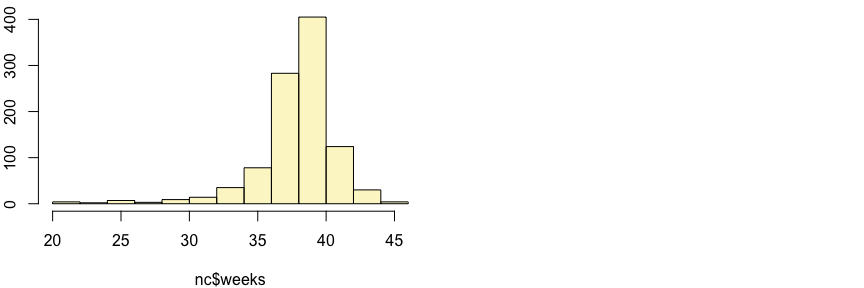

```
## mean = 38.3347 ;  sd = 2.9316 ;  n = 998
## Standard error = 0.0928
## 95 % Confidence interval = ( 38.1528 , 38.5165 )
```

- Calculate a new confidence interval for the same parameter at the 90% confidence level. You can change the confidence level by adding a new argument to the function: `conflevel = 0.90`.

*Conditions are the same as above.*

```r
inference(y = nc$weeks, est = "mean", type = "ci", method = "theoretical",
          conflevel = .90)
```

```
## Single mean
## Summary statistics:
```

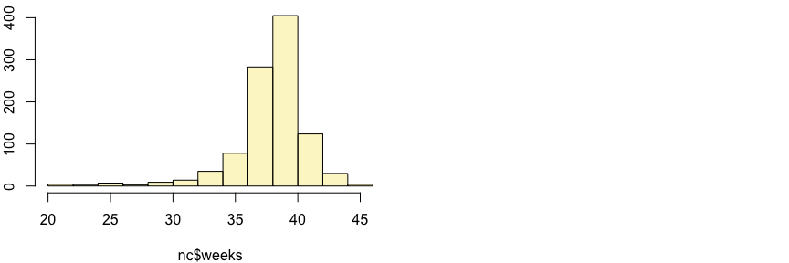

```
## mean = 38.3347 ;  sd = 2.9316 ;  n = 998
## Standard error = 0.0928
## 90 % Confidence interval = ( 38.182 , 38.4873 )
```

- Conduct a hypothesis test evaluating whether the average weight gained by younger mothers is different from the average weight gained by mature mothers. Be sure to state hypotheses.

$$H_0: \mu_{mature} - \mu_{younger} = 0$$
$$H_A: \mu_{mature} - \mu_{younger} \neq 0$$

*Where each $\mu$ represents the mean weight gained by the mothers in each group. As this is a random sample, our observations are independent. There is some right skew in the distribution of weight gains, but the sample size is sufficient that the nearly normal condition can be relaxed.*

```r
inference(y = nc$gained, x = nc$mature,
  est = "mean", type = "ht",
  alternative = "twosided", null = 0,
  method = "theoretical")
```

```
## Response variable: numerical, Explanatory variable: categorical
## Difference between two means
## Summary statistics:
## n_mature mom = 129, mean_mature mom = 28.7907, sd_mature mom = 13.4824
## n_younger mom = 844, mean_younger mom = 30.5604, sd_younger mom = 14.3469
```

```
## Observed difference between means (mature mom-younger mom) = -1.7697
##
## H0: mu_mature mom - mu_younger mom = 0
## HA: mu_mature mom - mu_younger mom != 0
## Standard error = 1.286
## Test statistic: Z =  -1.376
## p-value =  0.1686
```

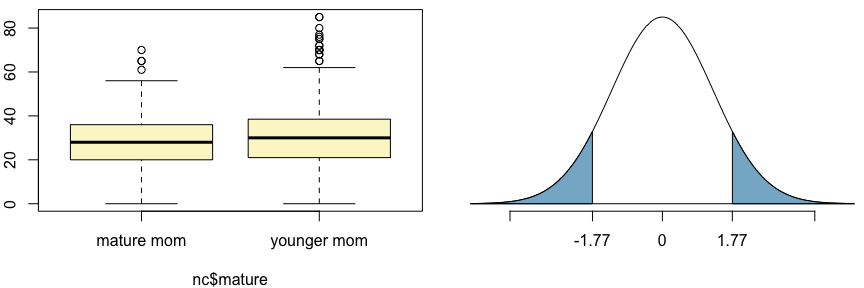

*With a p-value of .1686, the observed difference in weights was not significant at the $\alpha = .05$ level, therefore we fail to reject the null hypothesis that the two groups of mothers have the same mean weight gain.*

- Now, a non-inference task: Determine the age cutoff for younger and mature mothers. Use a method of your choice, and explain how your method works.

*I create a chain to group the `nc` data set by each category within the `mature` variable, then I find the min and max within each. We see that the youngest mature mothers are 35 and the oldest younger mothers are 34, which reveals the cutoff at 34/35.*

```r
nc %>%
  group_by(mature) %>%
  summarize(min(mage), max(mage))
```

```
## Source: local data frame [2 x 3]
##
##        mature min(mage) max(mage)
##        <fctr>     <int>     <int>
## 1  mature mom        35        50
## 2 younger mom        13        34
```

- Pick a pair of numerical and categorical variables and come up with a research question evaluating the relationship between these variables. Formulate the question in a way that it can be answered using a hypothesis test and/or a confidence interval. Please outline the hypotheses, utilize the `inference()` function, report the statistical results, and also provide an explanation in plain language.

*Is the pregnancy of male versus female children associated with a different average number of hospital visits, on average? This can be assessed by evaluating the following hypotheses.*

$$H_0: \mu_{male} - \mu_{female} = 0$$
$$H_A: \mu_{male} - \mu_{female} \neq 0$$

*Where each $\mu$ is the mean number of hospital visits during pregnancy within each group. In order for our test statistic to be well-approximated by the t (or normal) distribution, certain conditions should be met. Because the data arise from a random sample, the observations can be considered to be independent. The boxplots below show the data to be fairly symmetric about the center, therefore the nearly normal condition is met.*

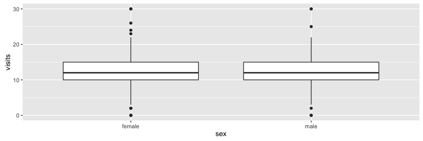

```r
qplot(x = sex, y = visits, data = nc, geom = "boxplot")
```

*Although there is very little difference evident in the plot, we continue on with the hypothesis test just to be sure.*

```r
inference(y = nc$visits, x = nc$sex, est = "mean", type = "ht", alternative = "twosided",
          method = "theoretical", null = 0)
```

```
## Response variable: numerical, Explanatory variable: categorical
## Difference between two means
## Summary statistics:
## n_female = 497, mean_female = 12.2636, sd_female = 4.131
## n_male = 494, mean_male = 11.9453, sd_male = 3.7669
```

```
## Observed difference between means (female-male) = 0.3182
##
## H0: mu_female - mu_male = 0
## HA: mu_female - mu_male != 0
## Standard error = 0.251
## Test statistic: Z =  1.267
## p-value =  0.205
```

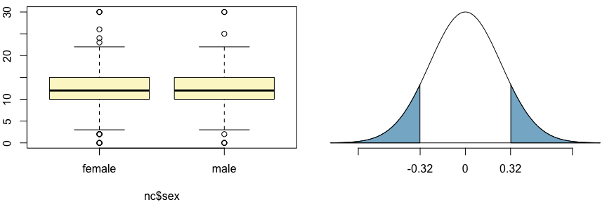

*The p-value is 0.205, so we fail to reject the null hypothesis at the .05 level. We find no strong evidence that the number of hospital visits made by a mother during pregnancy is associated with the sex of the baby.*

This is a product of OpenIntro that is released under a [Creative Commons Attribution-ShareAlike 3.0 Unported](http://creativecommons.org/licenses/by-sa/3.0). This lab was adapted for OpenIntro by Mine Çetinkaya-Rundel and Chester Ismay from a lab written by the faculty and TAs of UCLA Statistics.